# EP11 - Regresión Lineal Logística

### Confiabilidad (Modelo Pregunta 5)

Evaluando la confiabilidad del modelo de regresión logística, se deben considerar las siguientes condiciones:

#### Relacion lineal entre predictores y respuesta

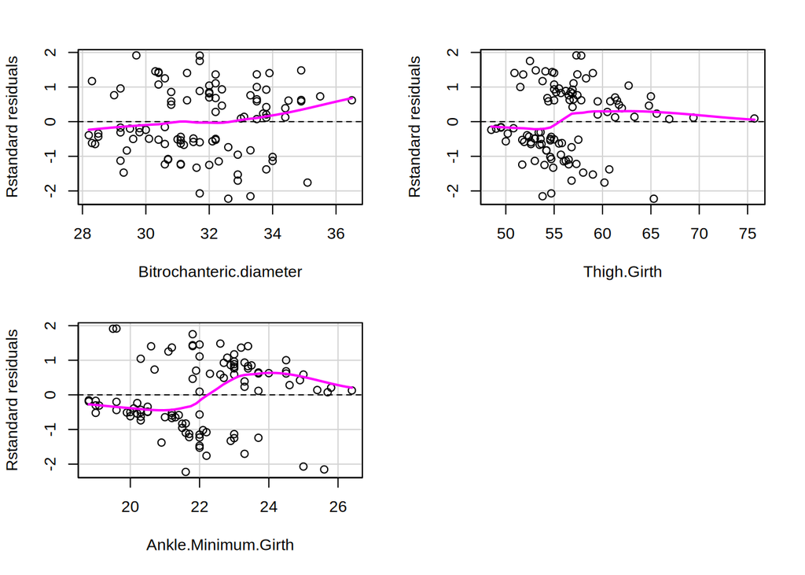

```
##                         Test stat Pr(>|Test stat|)
## Bitrochanteric.diameter    0.1356           0.7127
## Thigh.Girth                0.1613           0.6879
## Ankle.Minimum.Girth        0.1250           0.7236
```

```r
set.seed(21226)

# recrear modelo para usar plots mas facilmente
modelo_p5_v2 <- glm(EN ~ Bitrochanteric.diameter + Thigh.Girth + Ankle.Minimum.Girth, data = muestra_p5, family = binomial(link = "logit"))

residualPlots(modelo_p5_v2, fitted = FALSE, type = "rstandard")
```

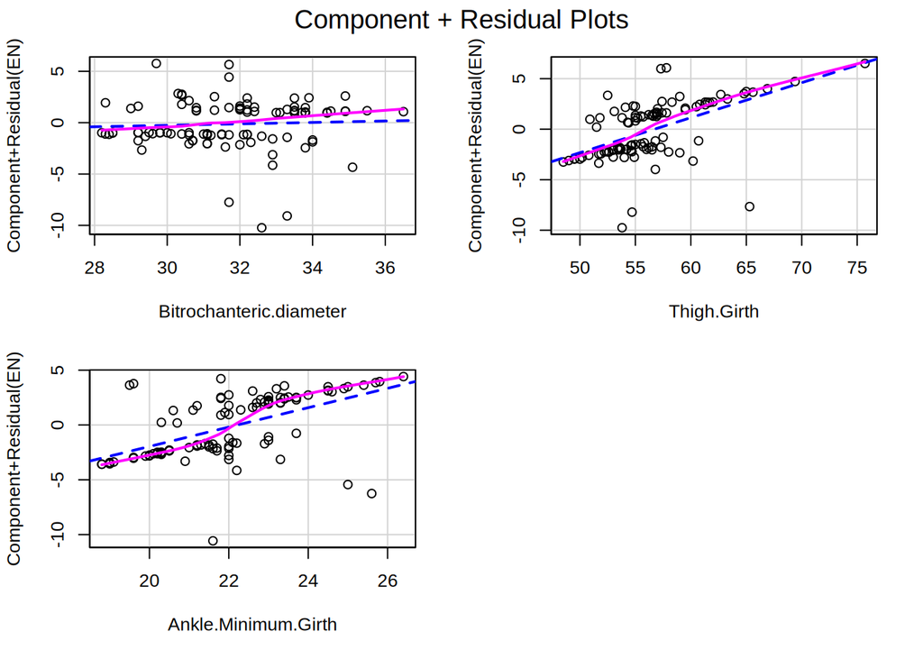

```r
crPlots(modelo_p5_v2)
```

El gráfico residual para cada predictor parece indicar que la linealidad se cumple aceptablemente para cada caso. Las pruebas de curvatura también indican que no hay evidencia suficiente para rechazar la hipótesis nula de linealidad.

Aunque, en el gráfico de residuos parciales, vemos que la variable Bitrochanteric.diameter parece no contribuir a los residuos de manera significativa, lo que podría indicar que no es un predictor relevante, agregando a lo sospechado en el inciso anterior. A pesar de esto, la variable se mantiene en el modelo por ser parte del conjunto de variables seleccionadas por RFE.

#### Residuos independientes

```r
set.seed(21226)
durbinWatsonTest(rlog)
```

```
##  lag Autocorrelation D-W Statistic p-value
##    1       0.1538824       1.68479   0.086
##  Alternative hypothesis: rho != 0
```

Dados los valores DW = 1.68479, cercano a 2; y p = 0.086, vemos que no hay evidencia suficiente para descartar que los residuos no tienen autocorrelación. Por ende, se cumple esta condición.

#### No multicolinealidad

```r
vif(rlog)
```

```
## Bitrochanteric.diameter             Thigh.Girth     Ankle.Minimum.Girth
##                1.241578                1.167104                1.159543
```

Todos los valores de VIF son cercanos a 1 por lo que nos despreocupamos de que exista una multicolinealidad severa entre los predictores.

#### Casos influyentes

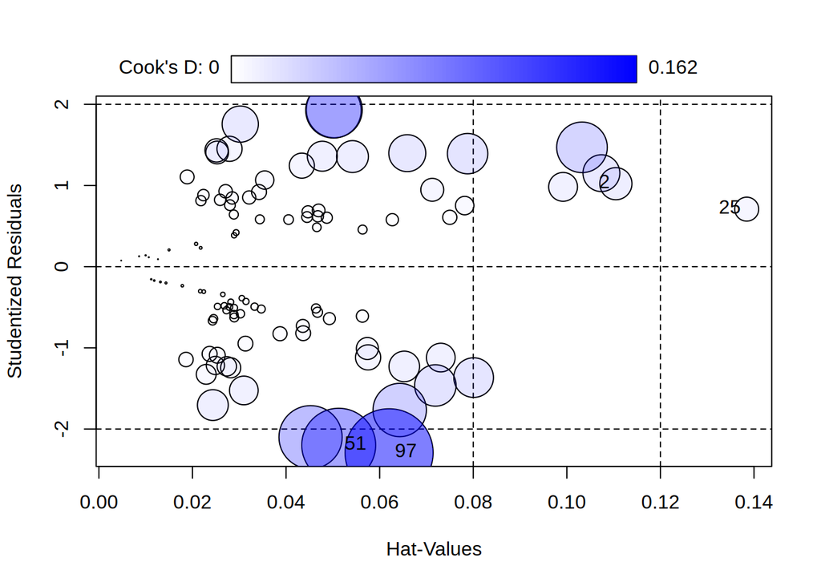

```r
set.seed(21226)

tabla_influencia <- influencePlot(rlog)
```

```r
umbral_hat <- 2 * mean(hatvalues(rlog))
umbral_cook <- 4 / nrow(muestra_p5)

# Agregar columnas para indicar si se pasan de los umbrales y por cuanto
tabla_influencia <- tabla_influencia %>%
  mutate(HighHat = Hat - umbral_hat, HighCook = CookD - umbral_cook) %>%
  arrange(desc(Hat)) %>%
  mutate(HighHat = ifelse(HighHat > 0, round(HighHat, digits = 5), ""),
         HighCook = ifelse(HighCook > 0, round(HighCook, digits = 5), ""))

print(tabla_influencia)
```

```
##       StudRes        Hat      CookD HighHat HighCook
## 25  0.7083827 0.13844046 0.01206434 0.05844
## 2   1.0220376 0.11047717 0.02171118 0.03048
## 97 -2.2924317 0.06201542 0.16226799          0.12227
## 51 -2.1993874 0.05125018 0.11442597          0.07443
```

Viendo el gráfico burbuja con las medidas de influencia para el modelo y la tabla respectiva con los valores, se destacan cuatro casos que parecen tener una influencia significativa en el modelo: **2**, **25**, **51**, y **97**. Los umbrales asociados a estas medidas corresponden a:

```r
sprintf("Umbral Hat = %.3f, Umbral Cook = %.3f", umbral_hat, umbral_cook)
```

```
## [1] "Umbral Hat = 0.080, Umbral Cook = 0.040"
```

Agregamos a la tabla dos columnas que indican cuánto sobrepasan cada medida el valor de su umbral en caso de hacerlo. Para 97 y 51, ambos tienen distancias de Cook altas, pero no se acercan a 1, considerado como valor crítico. Para 2 y 25, ambos sobrepasan el umbral para el apalancamiento, siendo este ultimo el más alejado, por lo que se consideran casos influyentes.

### Poder predictivo (Modelo Pregunta 5)

Para evaluar el poder predictivo del modelo, se utilizará la matriz de confusión evaluada con el conjunto de validación cruzada dejando uno fuera, y se calculará el AUC de la curva ROC.

```r
predicciones <- predict(rlog_rfe, muestra_p5)
matriz_conf <- confusionMatrix(predicciones[["pred"]], muestra_p5$EN, positive = "SI")
print(matriz_conf)
```

```
## Confusion Matrix and Statistics
##
##           Reference
## Prediction NO SI
##         NO 37 12
##         SI 13 38
##
##                Accuracy : 0.75
##                  95% CI : (0.6534, 0.8312)
##     No Information Rate : 0.5
##     P-Value [Acc > NIR] : 2.818e-07
##
##                   Kappa : 0.5
##
##  Mcnemar's Test P-Value : 1
##
##             Sensitivity : 0.7600
##             Specificity : 0.7400
##          Pos Pred Value : 0.7451
##          Neg Pred Value : 0.7551
##              Prevalence : 0.5000
##          Detection Rate : 0.3800
##    Detection Prevalence : 0.5100
##       Balanced Accuracy : 0.7500
##
##        'Positive' Class : SI
##
```

Pasando a graficar la curva ROC asociada:

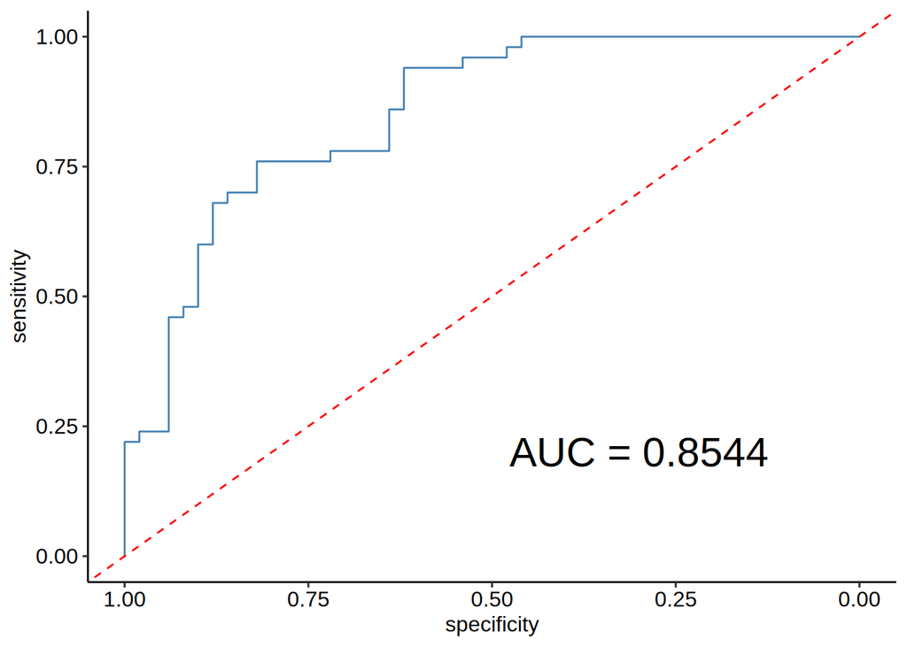

```r
curva_roc <- roc(muestra_p5$EN, predicciones[[2]], levels = c("NO", "SI"), direction = "<")
curva_roc_auc <- round(curva_roc$auc, 4)

plot_roc <- ggroc(curva_roc, col = "steelblue") +
  geom_abline(slope = 1, intercept = 1, linetype = "dashed", color = "red") +
  annotate("text", x = 0.3, y = 0.2,
           label = paste("AUC =", curva_roc_auc),
           color = "black", size = 8) +
  theme_pubr()

print(plot_roc)
```

El área bajo la curva ROC obtenida es de 0.8544, con sensibilidad = 0.76, especificidad = 0.74, lo que indica un buen rendimiento del modelo. Con los valores ya mencionados podemos declarar que el modelo es capaz de identificar correctamente verdaderos positivos y verdaderos negativos en un 76% y 74% de los casos respectivamente.